# Fungal microbiomes: a strategy for improved taxonomic resolution of environmental ITS sequences

Supplemental File 1

Gdanetz, VandePol, Bonito, and Benucci

## The analysis requires four general steps:

1. Sequence QC and OTU-picking
2. Database formatting and training
3. Taxonomy assignment
4. Post-taxonomy-assignment processing, filtering, analyzing

## **Step 1:** Sequence QC and OTU-Picking.

If beginning with raw sequence files, follow the OTU-picking steps below. If beginning with OTUs, skip to Step 2.

#### Required Programs:

- Python version 2.6 (or higher)
- PEAR version 0.9.8
- USEARCH version 8
- RDP version 11
- USEARCH version 9
- R and RStudio (newest version)

#### Run the Code:

```bash
## get quality statistics
fastqc ./*_R1_001.fastq
fastqc ./*_R2_001.fastq

## merge forward and reverse, change labels
usearch8 -fastq_mergepairs *_R1.fq -relabel @ -tabbedout merged_tabbed.txt -report merged_summary.txt -fastqout merged.fastq

## subsample reads
#download from https://github.com/lh3/seqtk
seqtk sample -s100 merged.fastq 500000 > sub.merged.fastq

## quality filter
usearch8 -fastq_eestats2 sub.merged.fastq -output merged.pre_filtered.eestats2.txt -length_cutoffs 100,400,10
usearch8 -fastq_filter sub.merged.fastq -fastq_minlen 150 -fastq_maxee 0.5 -fastaout merged.filtered.fa -fastaout_discarded merged.no_filter.fa -fastqout merged.filtered.fastq
usearch8 -fastq_eestats2 merged.filtered.fastq -output merged.post_filtered.eestats2.txt -length_cutoffs 150,400,10

## trim cleaned reads
usearch8 -fastx_truncate merged.filtered.fastq -padlen 250 -trunclen 250 -fastaout cleaned.fa

## find unique/representative sequences
usearch8 -derep_fulllength cleaned.fa -sizeout -fastaout derep.fa -threads 4

## cluster OTUs, remove singletons, de novo chimera check
usearch8 -cluster_otus derep.fa -minsize 2 -sizein -sizeout -relabel OTU_ -otus derep.otus.fa -uparseout reads.derep.otus.txt

## reference-based chimera check
# use for ITS1 region: uchime_sh_refs_dynamic_develop_985_01.01.2016.ITS1.fasta
# use for ITS2 region: uchime_sh_refs_dynamic_develop_985_01.01.2016.ITS2.fasta
# wget https://unite.ut.ee/sh_files/uchime_reference_dataset_01.01.2016.zip
usearch8 -uchime_ref derep.otus.fa -db /path_to_files/UNITE_db/uchime_sh_refs_dynamic_develop_985_01.01.2016.ITS2.fasta -nonchimeras otus.no_chimera.fa -uchimeout reads.derep.otus.no_chimera.uchime -strand plus -sizein -sizeout

## map reads back to OTUs and create the otu_tab.txt for phyloseq
usearch8 -usearch_global merged.filtered.fa -db otus.no_chimera.fa -strand plus -id 0.97 -top_hit_only -otutabout otu_table.txt -sizein -sizeout

## subsample OTUs to 500
seqtk sample -s100 otus.no_chimera.fa 500 > OTU_500.fa
```

#### Output Files:

- fasta file with all OTUs (otus.no_chimera.fa)
- subsetted fasta file (OTU_500.fa)

## **Step 2:** Pre-taxonomy-assignment database formatting and training.

#### Download the following python scripts from GitHub or supplemental files:

- *subscript_lineage2taxonomyTrain.py*
- *subscript_fasta_addFullLineage.py*
- *FormatRefDB.py*

#### Obtain a copy of the UNITE fungal database:

[Download database here](https://unite.ut.ee/repository.php)

#### Install the RDP Classifier following instructions available here:

[RDP Install](https://github.com/rdpstaff)

#### Run the Scripts.

Three python scripts listed above must be in the same directory with the database file:

```python
python FormatRefDB.py
```

#### Output Files:

1. Output files from utax database formatting
- utax_train.log
- utax_report.txt
- make_udb.log
- utax.31.01.2016.tc
- utax_db_31.01.2016.db
2. Output files from RDP formatting
- mytrained
- train.fasta
- train.txt
3. Output files from SINTAX formatting:
- none

## **Step 3:** Taxonomy assignment.

#### Input Files:

- Database files generated in Step 2
- OTU table(s)

#### Run Commands:

```bash
## assign taxonmy with utax
usearch8 -utax /path_to_files/RDP-UTAX/OTU_500.fa -db /path_to_files/unite_ref_db/utax_db_31_01_2016.db -strand both -utaxout /path_to_files/OTU_500.utax -utax_cutoff 0.8 -threads 6

## assign taxonomy with sintax
usearch9 -sintax /path_to_files/OTU_500.fa -db sintax_31_01_2016.udb -tabbedout /path_to_files/OTU_500.sintax -strand both -sintax_cutoff 0.8

## assign taxonmy with RDP Classifier
cd /path_to_files/RDP_installation/

java -Xmx5g -jar /path_to_files/mytrained/classifier.jar classify --conf 0.8 --format allrank --train_propfile /path_to_files/mytrained/rRNAClassifier.properties -o /path_to_files/OTU_500.rdp /path_to_files/OTU_500.fa
```

#### Output Files: Three taxonomy tables.

1. OTU_500.rdp
2. OTU_500.utax
3. OTU_500.sintax

## **Step 4:** Post-taxonomy-assignment OTU processing, filtering, analyzing.

#### Download the following python and R scripts from GitHub or supplemental files.

- *CombineTaxonomy.py*
- *Import.R*

### Run *CombineTaxonomy.py*

```python
python CombineTaxonomy.py
```

This script is interactive. First users will be prompted for cutoff threshold to filter taxonomy tables (the default is 0.8):

[figure not shown]

Then users will be prompted for the locations of each of the classifier outputs:

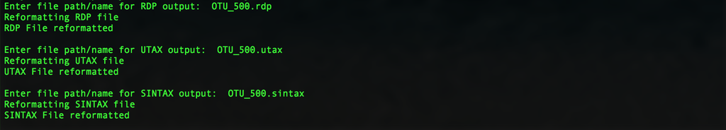

Finally the script will ask if the user would like to modify the default file names for the outputs:

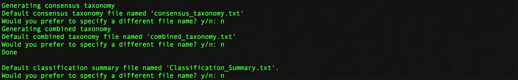

#### Format taxonomy outputs.

The taxonomy files from each classifier will modified to a new format, and all column labels will be identical:

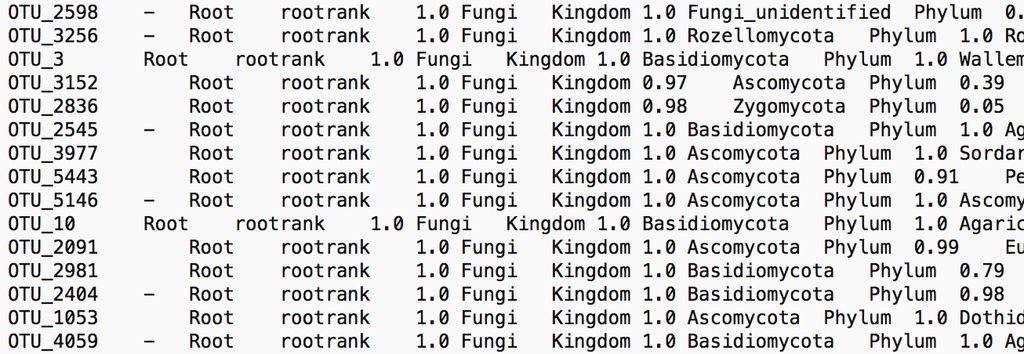

unfiltered RDP taxonomy table

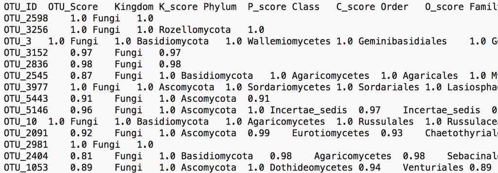

final RDP taxonomy table

#### Build consensus taxonomy.

The *CombineTaxonomy.py* script generates a *combined_taxonomy.txt* file that places all taxonomy table columns side-by-side in one larger taxonomy table:

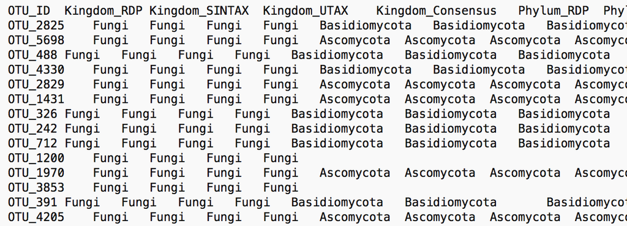

*CombineTaxonomy.py* also generates a *consensus_taxonomy.txt* file which parses over the *combined_taxonomy.txt* file, and selects the improved taxanomic classification using the rules outlined in the manuscript text (Table 3):

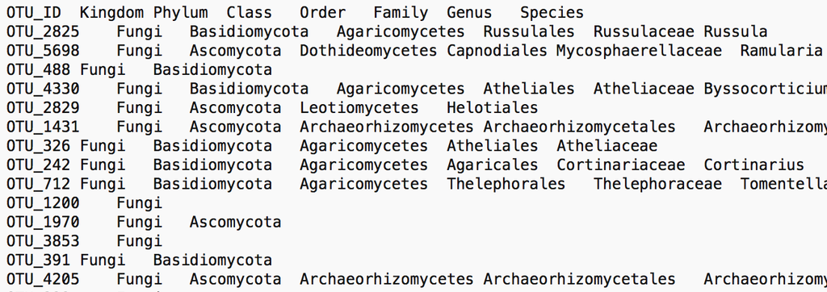

### Downstream Analysis.

#### Import files into R:

Run *Import.R* which imports data tables. Requires *combined_taxonomy.txt* tables.

First, load R packages:

```r
library(dplyr)
library(ggplot2)
```

Import file(s) and format data frame(s):

```r
data = read.table("~/path_to_files/combined_taxonomy.txt", header=TRUE, row.names=1, sep="\t")

data[data==''|data==' ']<-NA

sapply(data, function(x) sum(is.na(x))) -> unassigned_data
```

Calculate unidentified OTUs, assigned OTUs, and further format the data frame(s):

```r
data2 <- as.data.frame(unassigned_data)

data2$Classifier <- c("RDP","SINTAX","UTAX","COMBINED","RDP","SINTAX","UTAX","COMBINED","RDP","SINTAX","UTAX","COMBINED","RDP","SINTAX","UTAX","COMBINED","RDP","SINTAX","UTAX","COMBINED","RDP","SINTAX","UTAX","COMBINED","RDP","SINTAX","UTAX","COMBINED")

data2$Rank <- row.names(data2)

data2$Assigned <- sqrt((data2$unassigned_data -500)^2) #change 500 to number of OTUs

data2$Classifier <- factor(data2$Classifier, levels = c("RDP","UTAX","SINTAX","COMBINED"))
```

#### Generate Barplots:

Use ggplot to generate barplots as presented in Figure 2.

```r
ggplot(data2, aes(x = Rank, y = Assigned, fill= Classifier)) +
  geom_bar(stat = "identity") +
  scale_x_discrete(limits=data2$Rank) +
  theme(axis.text.x = element_text(angle = 90, hjust = 1),
        panel.grid=element_blank(),
        panel.background=element_blank()) +
  ggtitle("Assigned and Unidentified OTUs in ITS Dataset") +
  labs(x="Taxonomic Ranks", y="Number of classified OTUs")
```

[output not shown]

Repeat R code above for each ITS dataset.